# BIOL606_hw16_Shah.rmd

Priyanshi Shah

2023-04-17

#HOMEWORK

Info on the data: File contains data for 37 sites, surveyed for maximum abundance of 102 bird species in Australia Column 2 contains habitat type, divided into 6 types: Gippsland manna gum, montane forest, woodland, box-ironbark, river redgum, and mixed forest

```r
bird <- read.csv("macnally_full2.csv", header = TRUE, row.names = 1) #Loading the data
#View(bird) #Just checking out
bird$HABITAT = factor(bird$HABITAT)
#So we have total 103 columns
```

Run a NMDS on the bird data (macnally_full2.csv, leave out columns 1&2, SITE + HABITAT), using Bray-Curtis as the distance metric with the vegan metaMDS function

```r
#I can leave out columns 1 and 2 in two ways:
# by doing the (bird[,c(-1,-2)] or by selecting just the columns from 3 to 103 (in this case)

bird.nmds = metaMDS(bird[, c(3:103)], distance = 'bray', k = 2, trace = 0)
bird.nmds
```

```
##
## Call:
## metaMDS(comm = bird[, c(3:103)], distance = "bray", k = 2, trace = 0)
##
## global Multidimensional Scaling using monoMDS
##
## Data:     wisconsin(sqrt(bird[, c(3:103)]))
## Distance: bray
##
## Dimensions: 2
## Stress:     0.1175547
## Stress type 1, weak ties
## Best solution was repeated 2 times in 20 tries
## The best solution was from try 13 (random start)
## Scaling: centring, PC rotation, halfchange scaling
## Species: expanded scores based on 'wisconsin(sqrt(bird[, c(3:103)]))'
```

Generate a NMDS ordination plot showing the sites only (no species arrows), and draw ellipsoid hulls around each of the 6 habitat types to show how habitat maps onto the ordination. Color the site points by HABITAT type (column 2 of data frame)

Use the ordiellipse() function, and the groups argument should be defined using the HABITAT data in column 2 of the data frame Include a legend in the plot to show which point color maps to which habitat type

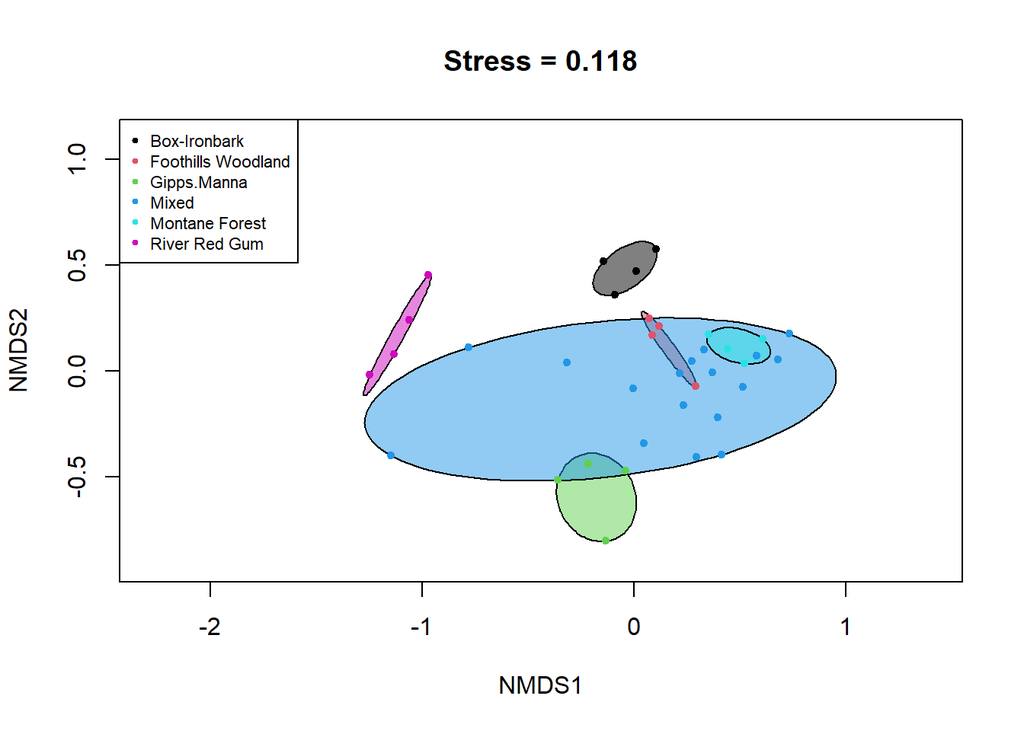

```r
bird_plot = ordiplot(bird.nmds, type='none',
        main = paste0('Stress = ',round(bird.nmds$stress,dig=3)))

ordiellipse(bird.nmds,kind='ehull',draw="polygon",
        groups=bird$HABITAT,label=F, col = 1:6)

points(bird_plot, what = 'sites', pch = 20, col = as.numeric(bird$HABITAT))

legend('topleft',legend=levels(bird$HABITAT), col = 1:6,
        pch = 20, cex = 0.7)
```

#Based on your plot, describe which (if any) of the habitats differ in community composition #Except for “Box-Ironbark” and “River Red Gum”, all the other habitats are somewhat clumped together in the community composition.

#CLASS WORK

```r
veg <- read.table("bryceveg.txt", header = TRUE, row.names = 1)

site <- read.table("brycesite.txt", header = TRUE, row.names= 1)


bc.nmds = metaMDS(veg, distance = 'bray', k =2, trace = 0)

bc.nmds
```

```
##
## Call:
## metaMDS(comm = veg, distance = "bray", k = 2, trace = 0)
##
## global Multidimensional Scaling using monoMDS
##
## Data:     veg
## Distance: bray
##
## Dimensions: 2
## Stress:     0.1405418
## Stress type 1, weak ties
## Best solution was not repeated after 20 tries
## The best solution was from try 19 (random start)
## Scaling: centring, PC rotation, halfchange scaling
## Species: expanded scores based on 'veg'
```

```r
#stress values below 0.2 are good, below 0.1 very good, 0 = excellent
#stress value tells you how well your multidimensional data matched upon the 2-D one
```

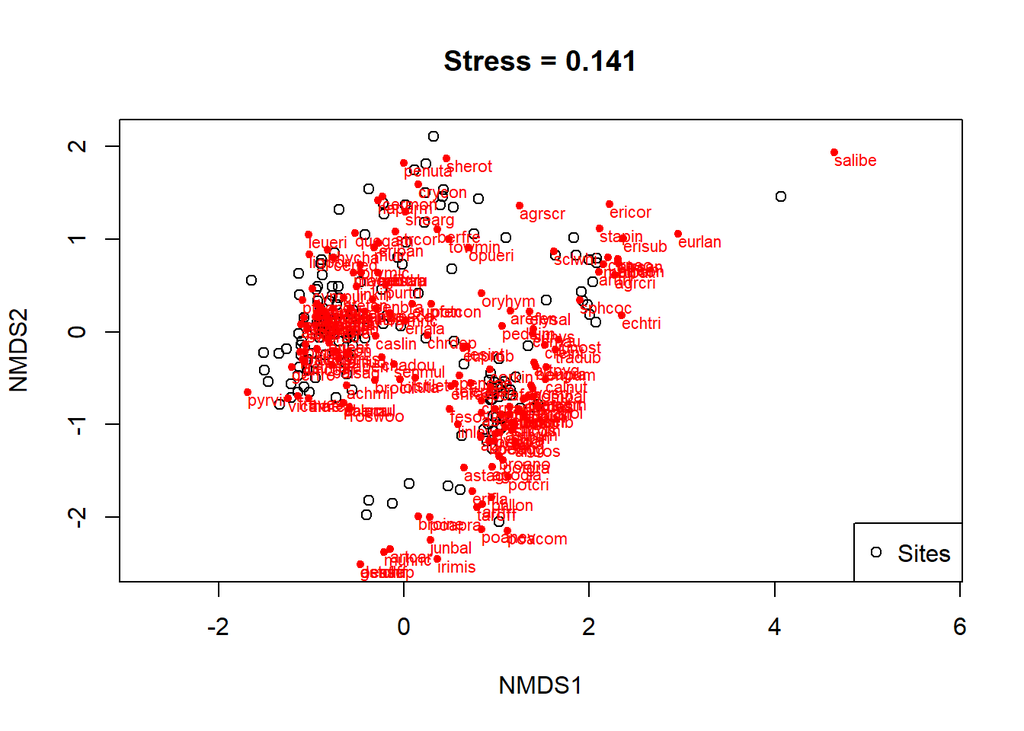

```r
p1 = ordiplot(bc.nmds, type = 'none',
              main = paste0('Stress = ',
                      round(bc.nmds$stress, dig= 3)))

points(p1, what = 'sites')
legend('bottomright', legend = c('Sites'),
       col = c('black'),
       pch = c(1, 20))


points(p1, what = 'species', col = 'red',
       pch = 20) #add species in red

text(p1, what = 'species', col = 'red',
     adj= c(0,1), cex = 0.7) #text labels
```